# Bike Case

2022-09-30

# Ask

**Company:** Cyclist Size: 5,824 Bicycles Year Launched: 2016

**Number of Stations:** 692

**State of Operation:** Chicago

**Goal:** Design marketing Strategies aimed at converting casual riders into annual members.

**Business Task:** To determine how do annual members and casual riders use Cyclistic bikes differently

#Prepare

1. Best place to store the data would be in the Google Cloud Platform
2. This allows me to organize all the tables and compile them together with the use of Big Query.
3. This allows for easy access of data since everything is stored in the cloud.
4. This allows for protection of data ensuring that the data follows encryption practices.

The data contains the following columns, this information would determine the ride habits of both members and non members.

1. Ride ID
2. Rideable Type
3. Started At
4. Ended At
5. Start Station Name
6. Start Station ID
7. End Station Name
8. End Station ID
9. Start Latitude
10. Start Longitude
11. End Latitude
12. End Longitude
13. Member Casual

The data from each month was compiled into a singular table in order to better analyze the data.

*First a new table was created to store the data*

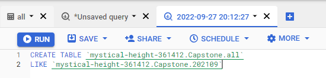

*Then a combination of UNION ALL statements were used to compile the data*

[figure not shown]

# Process

## Step 1: Install Packages

```r
library(tidyverse)
library(dplyr)
library(lubridate)
library(scales)
library(tinytex)
```

## Step 2: Read CSV and Convert Values to String

```r
processed_tripdata <- read_csv(file = paste("bikedata.csv", sep=""))
str(processed_tripdata)
```

```
## spec_tbl_df [5,920,599 × 13] (S3: spec_tbl_df/tbl_df/tbl/data.frame)
##  $ ride_id           : chr [1:5920599] "A535F2E03A1D8A04" "8F1611A8E1DA38D4" "B9B7D65816A280A3" "8D511BDDC0740DBC" ...
##  $ rideable_type     : chr [1:5920599] "classic_bike" "classic_bike" "docked_bike" "classic_bike" ...
##  $ started_at        : chr [1:5920599] "2021-09-21 19:57:57 UTC" "2022-03-26 14:51:34 UTC" "2022-03-20 10:48:02 UTC" "2022-04-11 09:27:45 UTC" ...
##  $ ended_at          : chr [1:5920599] "2021-09-22 13:09:20 UTC" "2022-03-27 15:51:29 UTC" "2022-03-20 11:48:52 UTC" "2022-04-12 10:27:37 UTC" ...
##  $ start_station_name: chr [1:5920599] "Sheffield Ave & Wellington Ave" "Blackstone Ave & Hyde Park Blvd" "Buckingham Fountain" "Rush St & Cedar St" ...
##  $ start_station_id  : logi [1:5920599] NA NA NA NA NA NA ...
##  $ end_station_name  : chr [1:5920599] NA NA NA NA ...
##  $ end_station_id    : chr [1:5920599] NA NA NA NA ...
##  $ start_lat         : num [1:5920599] 41.9 41.8 41.9 41.9 41.9 ...
##  $ start_lng         : num [1:5920599] -87.7 -87.6 -87.6 -87.6 -87.6 ...
##  $ end_lat           : num [1:5920599] NA NA NA NA NA NA NA NA NA NA ...
##  $ end_lng           : num [1:5920599] NA NA NA NA NA NA NA NA NA NA ...
##  $ member_casual     : chr [1:5920599] "casual" "casual" "casual" "casual" ...
##  - attr(*, "spec")=
##   .. cols(
##   ..   ride_id = col_character(),
##   ..   rideable_type = col_character(),
##   ..   started_at = col_character(),
##   ..   ended_at = col_character(),
##   ..   start_station_name = col_character(),
##   ..   start_station_id = col_logical(),
##   ..   end_station_name = col_character(),
##   ..   end_station_id = col_character(),
##   ..   start_lat = col_double(),
##   ..   start_lng = col_double(),
##   ..   end_lat = col_double(),
##   ..   end_lng = col_double(),
##   ..   member_casual = col_character()
##   .. )
##  - attr(*, "problems")=<externalptr>
```

## Step 3: Format Columns

```r
processed_tripdata$started_at <- ymd_hms(processed_tripdata$started_at)
processed_tripdata$ended_at <- ymd_hms(processed_tripdata$ended_at)
processed_tripdata$duration <- as.numeric(difftime(processed_tripdata$ended_at, processed_tripdata$started_at, units="min"))
processed_tripdata$month <- format(processed_tripdata$started_at, format="%B")
#Formats into month name
processed_tripdata$day_of_week <- format(processed_tripdata$started_at, format="%A")
#Formats into weekday name
processed_tripdata$hour <- format(processed_tripdata$started_at, format="%H")
#Formats into hour in 24 hour format
processed_tripdata <- processed_tripdata %>% filter(duration > 0)
#Remove trips that have a duration of 0 and less
processed_tripdata$member_casual<-replace(processed_tripdata$member_casual,processed_tripdata$member_casual=="casual","Casual")
processed_tripdata$member_casual<-replace(processed_tripdata$member_casual,processed_tripdata$member_casual=="member","Member")
#Change the casing of the member_casual variable
options(scipen=999)
#To use decimals instead of scientific notation
```

# Analyze

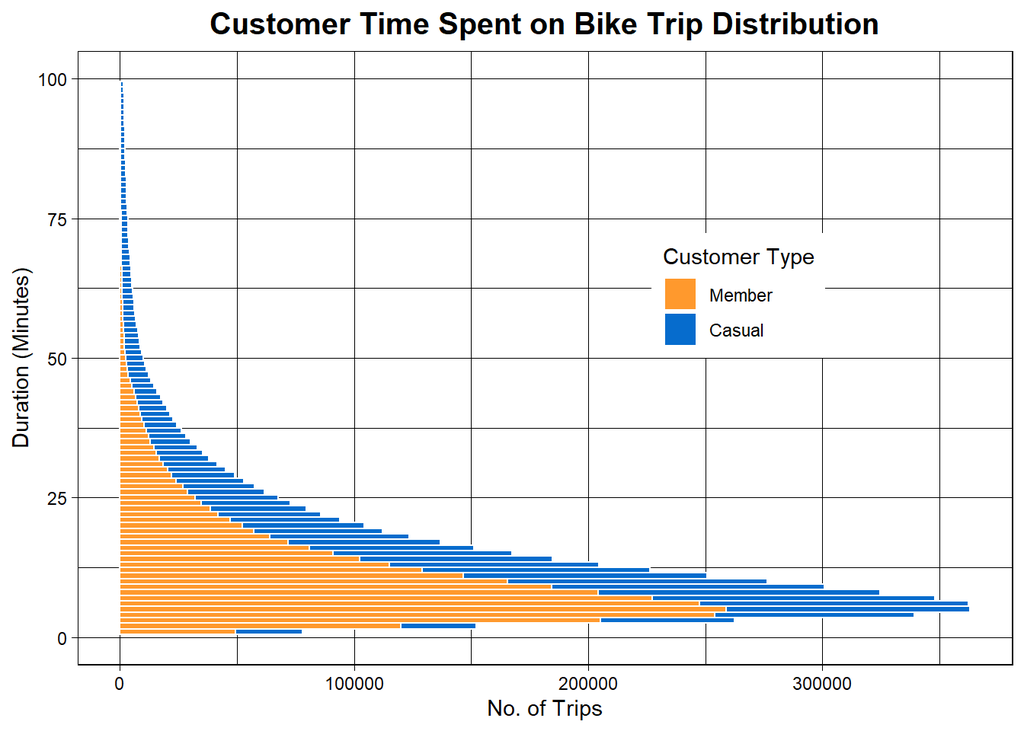

```r
#This plot shows the distribution of customers both members and casual riders, across the duration of each bike trip.
ggplot(processed_tripdata, aes(x=duration, fill=member_casual)) +
    geom_histogram(binwidth = 1, color="white") +
    xlim(0, 100) +
    xlab("Duration (Minutes)") +
    ylab("No. of Trips") +
    theme_linedraw() +
    ggtitle("Customer Time Spent on Bike Trip Distribution") +
    theme(plot.title = element_text(size = 15, face = "bold", hjust = 0.5),
            legend.justification = c(1,0),
            legend.position = c(0.8,0.5)
         ) +
    guides(fill=guide_legend(title="Customer Type")) +
    scale_fill_manual(values=c('#FF992D','#066CCD'), limits = c("Member", "Casual")) +
    coord_flip()
```

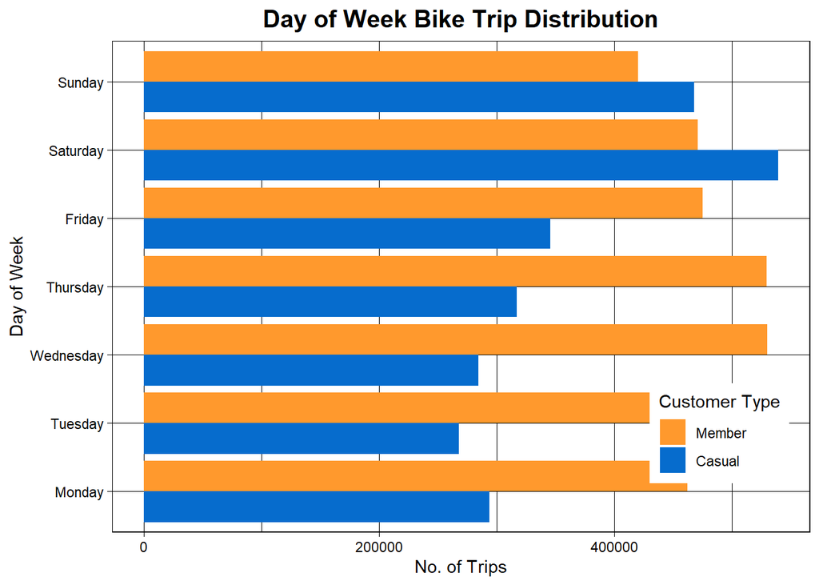

```r
#This plot shows the distribution of customers both members and casual riders, across the numbers of trips per day of the week
processed_tripdata %>%
    select(day_of_week, member_casual) %>%
    group_by(day_of_week, member_casual) %>%
    count() %>%
    ggplot(aes(x=factor(day_of_week, level=c('Monday', 'Tuesday', 'Wednesday', 'Thursday',
                                               'Friday', 'Saturday', 'Sunday')),
               y=n, fill=member_casual)) +
        geom_bar(stat="identity", position=position_dodge())+
        coord_flip()+
        scale_fill_manual(values=c('#FF992D','#066CCD'), limits = c("Member", "Casual")) +
        xlab("Day of Week") +
        ylab("No. of Trips") +
        theme_linedraw() +
        ggtitle("Day of Week Bike Trip Distribution") +
        guides(fill=guide_legend(title="Customer Type")) +
        theme(plot.title = element_text(size = 15, face = "bold", hjust = 0.5),
                legend.justification = c(1,0),
                legend.position = c(0.97,0.1)
             )
```

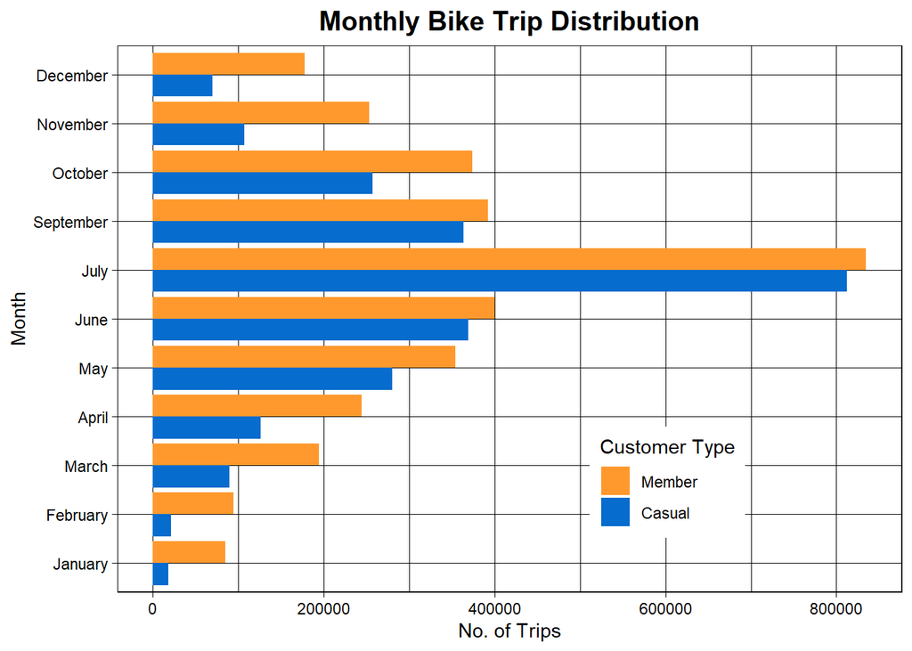

```r
#This plot shows the distribution of customers both members and casual riders, across the numbers of trips per month
processed_tripdata %>%
    select(month, member_casual) %>%
    group_by(month, member_casual) %>%
    count() %>%
    ggplot(aes(x=factor(month, level=c('January', 'February', 'March', 'April', 'May',
                                         'June', 'July', 'August', 'September', 'October', 'November', 'December')),
                        y=n, fill=member_casual)) +
        geom_bar(stat="identity", position=position_dodge())+
        coord_flip()+
        scale_fill_manual(values=c('#FF992D','#066CCD'), limits = c("Member", "Casual")) +
        xlab("Month") +
        ylab("No. of Trips") +
        theme_linedraw() +
        ggtitle("Monthly Bike Trip Distribution") +
        guides(fill=guide_legend(title="Customer Type")) +
        theme(plot.title = element_text(size = 15, face = "bold", hjust = 0.5),
                legend.justification = c(1,0),
                legend.position = c(0.8,0.1)
             )
```

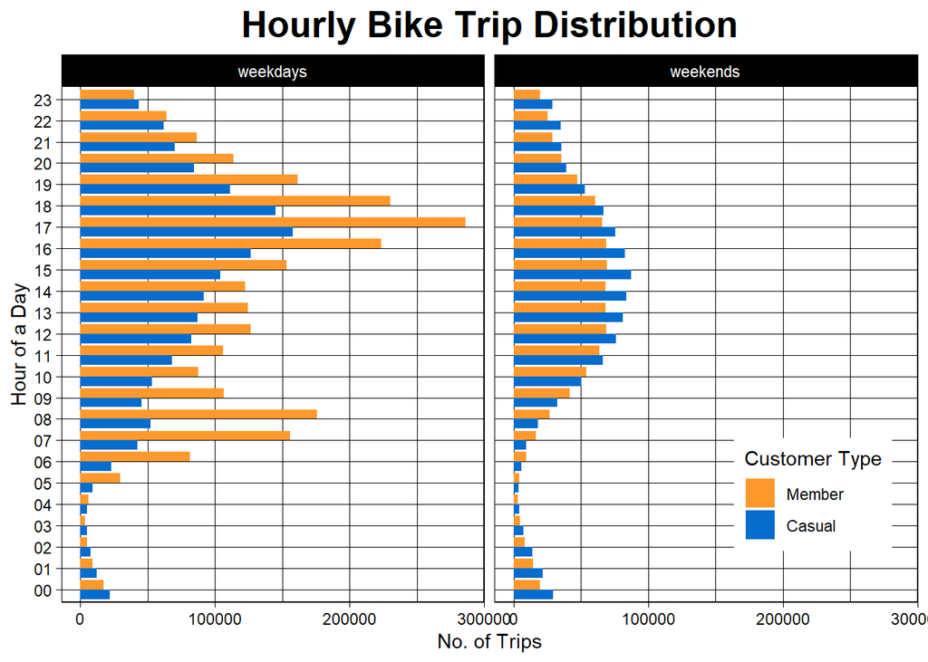

```r
#These plots show the number of hours in a day members and casual customers ride bikes on both weekdays and weekends.
weekend <- processed_tripdata %>%
    select(day_of_week, hour, member_casual) %>%
    filter(day_of_week == 'Saturday' | day_of_week == 'Sunday') %>%
    group_by(hour, member_casual) %>%
    count()

weekend$weekend_weekday = 'weekends'

weekday <- processed_tripdata %>%
    select(day_of_week, hour, member_casual) %>%
    filter(day_of_week != 'Saturday' & day_of_week != 'Sunday') %>%
    group_by(hour, member_casual) %>%
    count()

weekday$weekend_weekday = 'weekdays'

weekend <- rbind(weekend, weekday)

weekend %>%
    ggplot(aes(x=hour, y=n, fill=member_casual)) +
        geom_bar(stat="identity", position=position_dodge())+
        coord_flip()+
        scale_fill_manual(values=c('#FF992D','#066CCD'), limits = c("Member", "Casual")) +
        xlab("Hour of a Day") +
        ylab("No. of Trips") +
        theme_linedraw() +
        ggtitle("Hourly Bike Trip Distribution") +
        guides(fill=guide_legend(title="Customer Type")) +
        theme(plot.title = element_text(size = 20, face = "bold", hjust = 0.5),
                legend.justification = c(1,0),
                legend.position = c(0.97,0.1)
             ) +
        facet_wrap(~weekend_weekday)
```

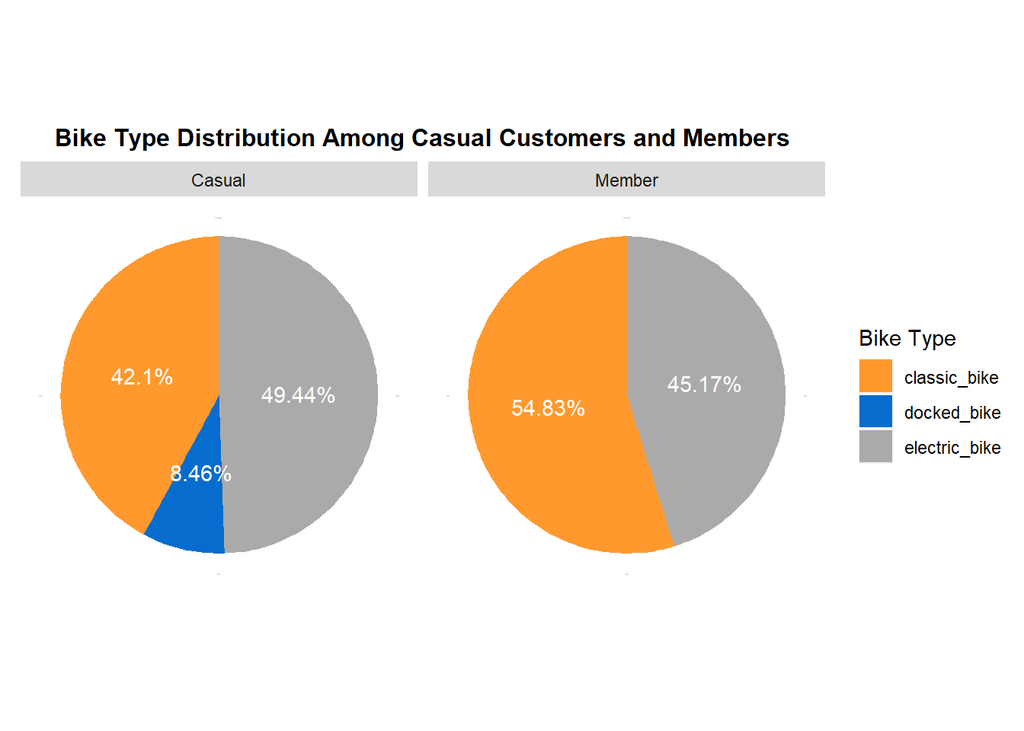

```r
#These plots shows the distribution of customers both members and casual riders, across the different bike types
casual <- processed_tripdata %>%
    select(member_casual, rideable_type) %>%
    filter(member_casual == "Casual") %>%
    group_by(rideable_type, member_casual) %>%
    count()

member <- processed_tripdata %>%
    select(member_casual, rideable_type) %>%
    filter(member_casual == "Member") %>%
    group_by(rideable_type, member_casual) %>%
    count()

customer <- rbind((casual%>%mutate(countT= sum(casual$n)) %>%
              group_by(rideable_type, add=TRUE) %>%
              mutate(per=n/countT, per_label=paste0(round(100*n/countT,2),"%"))),
             (member%>%mutate(countT= sum(member$n)) %>%
              group_by(rideable_type, add=TRUE) %>%
              mutate(per=n/countT, per_label=paste0(round(100*n/countT,2),"%"))))
ggplot(customer, aes(x="", y=per, fill=rideable_type)) +
        geom_col() +
        coord_polar(theta = "y") +
        scale_y_continuous(labels = scales::percent) +
        geom_text(aes(label = per_label), position = position_stack(vjust = 0.5), color="white") +
        scale_fill_manual(values=c('#FF992D','#066CCD','#AAAAAA'), limits = c("classic_bike", "docked_bike", "electric_bike")) +
        theme(axis.ticks = element_blank(),
            axis.title = element_blank(),
            axis.text = element_text(size = 0),
            panel.background = element_rect(fill = "white"),
            plot.title = element_text(size = 12, face = "bold", hjust = 0.5)) +
        ggtitle("Bike Type Distribution Among Casual Customers and Members") +
        guides(fill=guide_legend(title="Bike Type")) +
        facet_wrap(~member_casual)
```

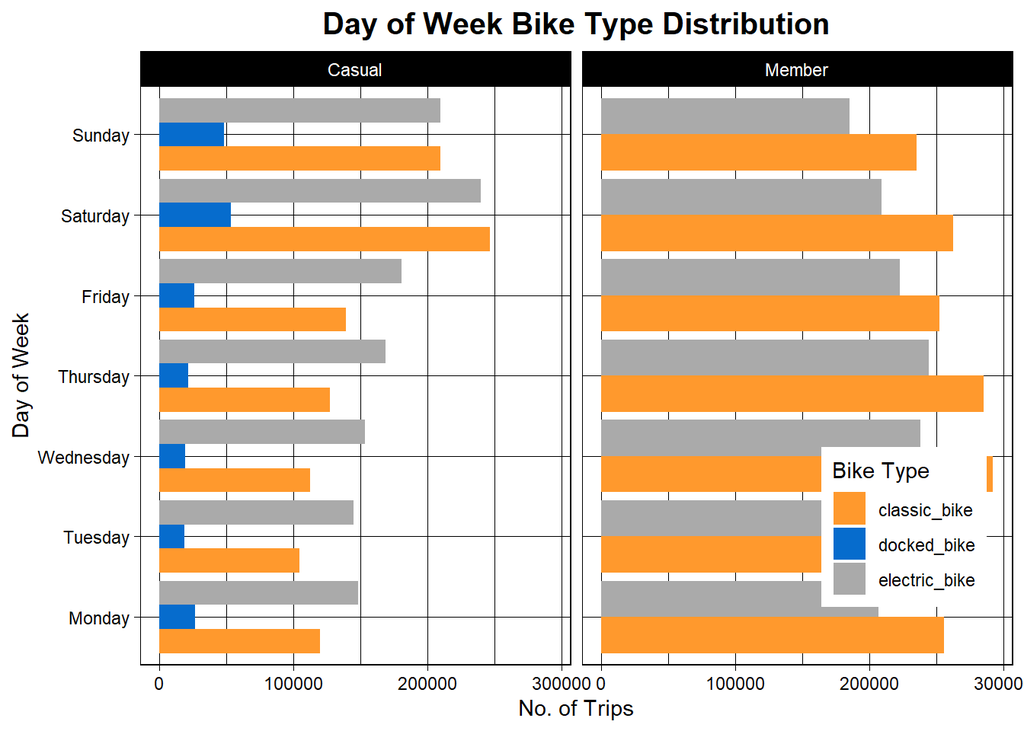

```r
#These plots shows the distribution of the different bike types based on the day of the week
processed_tripdata %>%
    select(day_of_week, rideable_type, member_casual) %>%
    group_by(day_of_week, rideable_type, member_casual) %>%
    count() %>%
    ggplot(aes(x=factor(day_of_week, level=c('Monday', 'Tuesday', 'Wednesday', 'Thursday',
                                               'Friday', 'Saturday', 'Sunday')),
               y=n, fill=rideable_type)) +
        geom_bar(stat="identity", position=position_dodge())+
        coord_flip()+
        scale_fill_manual(values=c('#FF992D','#066CCD','#AAAAAA'), limits = c("classic_bike","docked_bike","electric_bike")) +
        xlab("Day of Week") +
        ylab("No. of Trips") +
        theme_linedraw() +
        ggtitle("Day of Week Bike Type Distribution") +
        guides(fill=guide_legend(title="Bike Type")) +
        theme(plot.title = element_text(size = 15, face = "bold", hjust = 0.5),
                legend.justification = c(1,0),
                legend.position = c(0.97,0.1)
             ) +
        facet_wrap(~member_casual)
```

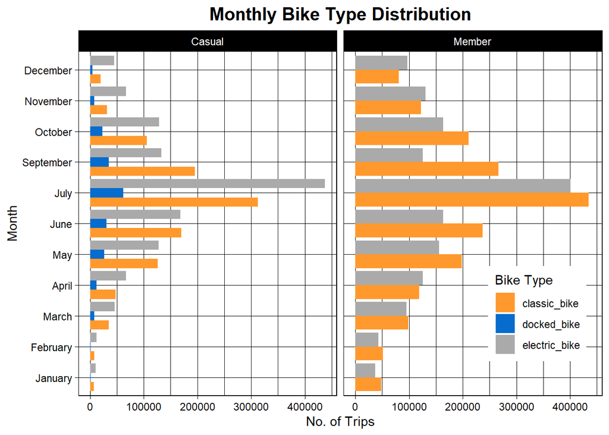

```r
#These plots shows the distribution of the different bike types based on the month
processed_tripdata %>%
    select(month, rideable_type, member_casual) %>%
    group_by(month, rideable_type, member_casual) %>%
    count() %>%
    ggplot(aes(x=factor(month, level=c('January', 'February', 'March', 'April', 'May',
                                         'June', 'July', 'August', 'September', 'October', 'November', 'December')),
               y=n, fill=rideable_type)) +
        geom_bar(stat="identity", position=position_dodge())+
        coord_flip()+
        scale_fill_manual(values=c('#FF992D','#066CCD','#AAAAAA'), limits = c("classic_bike", "docked_bike", "electric_bike")) +
        xlab("Month") +
        ylab("No. of Trips") +
        theme_linedraw() +
        ggtitle("Monthly Bike Type Distribution") +
        guides(fill=guide_legend(title="Bike Type")) +
        theme(plot.title = element_text(size = 15, face = "bold", hjust = 0.5),
                legend.justification = c(1,0),
                legend.position = c(0.97,0.1)
             ) +
        facet_wrap(~member_casual)
```